# Quiz: Diamonds

1. Load the ‘diamonds’ data set in R Studio. How many observations are in the data set?

```r
library(ggplot2)
data("diamonds")
```

```r
summary(diamonds)
```

```
##      carat               cut        color        clarity
##  Min.   :0.2000   Fair     : 1610   D: 6775   SI1    :13065
##  1st Qu.:0.4000   Good     : 4906   E: 9797   VS2    :12258
##  Median :0.7000   Very Good:12082   F: 9542   SI2    : 9194
##  Mean   :0.7979   Premium  :13791   G:11292   VS1    : 8171
##  3rd Qu.:1.0400   Ideal    :21551   H: 8304   VVS2   : 5066
##  Max.   :5.0100                     I: 5422   VVS1   : 3655
##                                     J: 2808   (Other): 2531
##      depth           table           price             x
##  Min.   :43.00   Min.   :43.00   Min.   :  326   Min.   : 0.000
##  1st Qu.:61.00   1st Qu.:56.00   1st Qu.:  950   1st Qu.: 4.710
##  Median :61.80   Median :57.00   Median : 2401   Median : 5.700
##  Mean   :61.75   Mean   :57.46   Mean   : 3933   Mean   : 5.731
##  3rd Qu.:62.50   3rd Qu.:59.00   3rd Qu.: 5324   3rd Qu.: 6.540
##  Max.   :79.00   Max.   :95.00   Max.   :18823   Max.   :10.740
##
##        y                z
##  Min.   : 0.000   Min.   : 0.000
##  1st Qu.: 4.720   1st Qu.: 2.910
##  Median : 5.710   Median : 3.530
##  Mean   : 5.735   Mean   : 3.539
##  3rd Qu.: 6.540   3rd Qu.: 4.040
##  Max.   :58.900   Max.   :31.800
##
```

```r
dim(diamonds)
```

```
## [1] 53940    10
```

53940 observations

2. How many variables are in the data set?

-> 10

3. How many ordered factors are in the data set?

```r
str(diamonds)
```

```
## Classes 'tbl_df', 'tbl' and 'data.frame':    53940 obs. of  10 variables:
##  $ carat  : num  0.23 0.21 0.23 0.29 0.31 0.24 0.24 0.26 0.22 0.23 ...
##  $ cut    : Ord.factor w/ 5 levels "Fair"<"Good"<..: 5 4 2 4 2 3 3 3 1 3 ...
##  $ color  : Ord.factor w/ 7 levels "D"<"E"<"F"<"G"<..: 2 2 2 6 7 7 6 5 2 5 ...
##  $ clarity: Ord.factor w/ 8 levels "I1"<"SI2"<"SI1"<..: 2 3 5 4 2 6 7 3 4 5 ...
##  $ depth  : num  61.5 59.8 56.9 62.4 63.3 62.8 62.3 61.9 65.1 59.4 ...
##  $ table  : num  55 61 65 58 58 57 57 55 61 61 ...
##  $ price  : int  326 326 327 334 335 336 336 337 337 338 ...
##  $ x      : num  3.95 3.89 4.05 4.2 4.34 3.94 3.95 4.07 3.87 4 ...
##  $ y      : num  3.98 3.84 4.07 4.23 4.35 3.96 3.98 4.11 3.78 4.05 ...
##  $ z      : num  2.43 2.31 2.31 2.63 2.75 2.48 2.47 2.53 2.49 2.39 ...
```

-> 3

4. What letter represents the best color for a diamond?

```r
levels(diamonds$color)
```

```
## [1] "D" "E" "F" "G" "H" "I" "J"
```

```r
?diamonds
```

## Price Histogram

Create a histogram of the price of all the diamonds in the diamond data set.

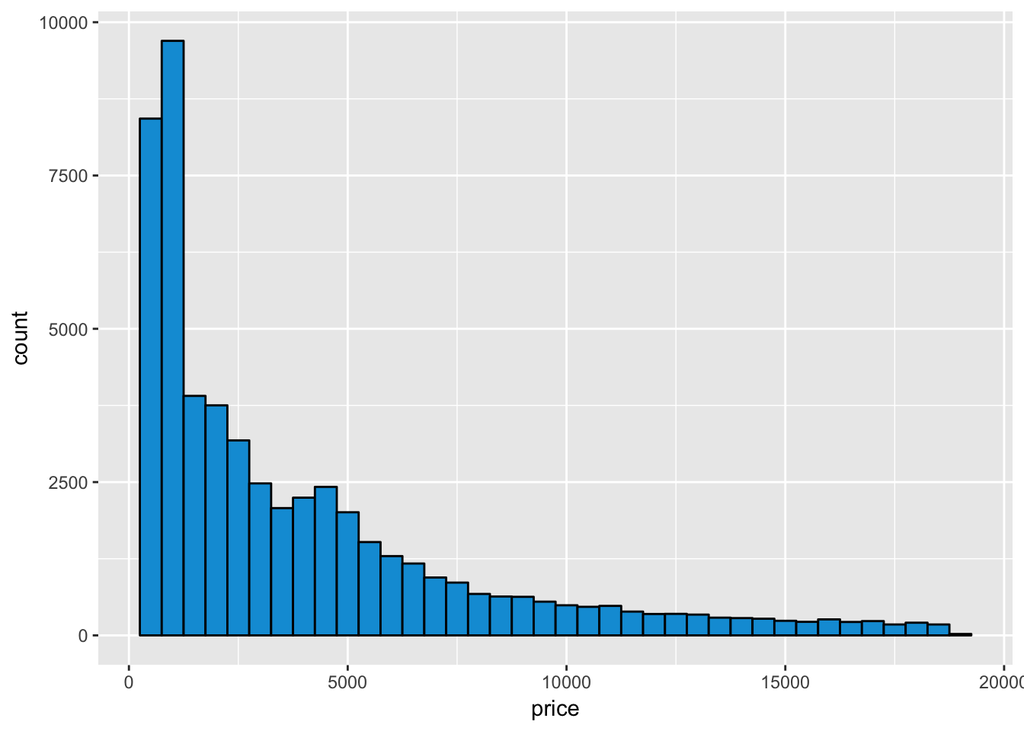

```r
qplot(data=diamonds, x=price, binwidth=500,
      color = I('black'), fill = I('#099DD9'))
```

## Price Histogram Summary

Describe the shape and center of the price distribution. Include summary statistics like the mean and median.

```r
summary(diamonds)
```

```
##      carat               cut        color        clarity
##  Min.   :0.2000   Fair     : 1610   D: 6775   SI1    :13065
##  1st Qu.:0.4000   Good     : 4906   E: 9797   VS2    :12258
##  Median :0.7000   Very Good:12082   F: 9542   SI2    : 9194
##  Mean   :0.7979   Premium  :13791   G:11292   VS1    : 8171
##  3rd Qu.:1.0400   Ideal    :21551   H: 8304   VVS2   : 5066
##  Max.   :5.0100                     I: 5422   VVS1   : 3655
##                                     J: 2808   (Other): 2531
##      depth           table           price             x
##  Min.   :43.00   Min.   :43.00   Min.   :  326   Min.   : 0.000
##  1st Qu.:61.00   1st Qu.:56.00   1st Qu.:  950   1st Qu.: 4.710
##  Median :61.80   Median :57.00   Median : 2401   Median : 5.700
##  Mean   :61.75   Mean   :57.46   Mean   : 3933   Mean   : 5.731
##  3rd Qu.:62.50   3rd Qu.:59.00   3rd Qu.: 5324   3rd Qu.: 6.540
##  Max.   :79.00   Max.   :95.00   Max.   :18823   Max.   :10.740
##
##        y                z
##  Min.   : 0.000   Min.   : 0.000
##  1st Qu.: 4.720   1st Qu.: 2.910
##  Median : 5.710   Median : 3.530
##  Mean   : 5.735   Mean   : 3.539
##  3rd Qu.: 6.540   3rd Qu.: 4.040
##  Max.   :58.900   Max.   :31.800
##
```

## Diamond Counts

1. How many diamonds cost less than $500?

```r
subset(diamonds, price < 500)
```

```
## # A tibble: 1,729 × 10
##    carat       cut color clarity depth table price     x     y     z
##    <dbl>     <ord> <ord>   <ord> <dbl> <dbl> <int> <dbl> <dbl> <dbl>
## 1   0.23     Ideal     E     SI2  61.5    55   326  3.95  3.98  2.43
## 2   0.21   Premium     E     SI1  59.8    61   326  3.89  3.84  2.31
## 3   0.23      Good     E     VS1  56.9    65   327  4.05  4.07  2.31
## 4   0.29   Premium     I     VS2  62.4    58   334  4.20  4.23  2.63
## 5   0.31      Good     J     SI2  63.3    58   335  4.34  4.35  2.75
## 6   0.24 Very Good     J    VVS2  62.8    57   336  3.94  3.96  2.48
## 7   0.24 Very Good     I    VVS1  62.3    57   336  3.95  3.98  2.47
## 8   0.26 Very Good     H     SI1  61.9    55   337  4.07  4.11  2.53
## 9   0.22      Fair     E     VS2  65.1    61   337  3.87  3.78  2.49
## 10  0.23 Very Good     H     VS1  59.4    61   338  4.00  4.05  2.39
## # ... with 1,719 more rows
```

2. How many diamonds cost less than $250?

```r
subset(diamonds, price < 250)
```

```
## # A tibble: 0 × 10
## # ... with 10 variables: carat <dbl>, cut <ord>, color <ord>,
## #   clarity <ord>, depth <dbl>, table <dbl>, price <int>, x <dbl>,
## #   y <dbl>, z <dbl>
```

3. How many diamonds cost $15,000 or more?

```r
subset(diamonds, price >= 15000)
```

```
## # A tibble: 1,656 × 10
##    carat       cut color clarity depth table price     x     y     z
##    <dbl>     <ord> <ord>   <ord> <dbl> <dbl> <int> <dbl> <dbl> <dbl>
## 1   1.60     Ideal     G     VS2  61.9    56 15000  7.53  7.47  4.64
## 2   1.54   Premium     E     VS2  62.3    58 15002  7.31  7.39  4.58
## 3   1.19     Ideal     F    VVS1  61.5    55 15005  6.82  6.84  4.20
## 4   2.10   Premium     I     SI1  61.5    57 15007  8.25  8.21  5.06
## 5   1.69     Ideal     D     SI1  60.8    57 15011  7.69  7.71  4.68
## 6   1.50 Very Good     G    VVS2  62.9    56 15013  7.22  7.32  4.57
## 7   1.73 Very Good     G     VS1  62.8    57 15014  7.57  7.72  4.80
## 8   2.02   Premium     G     SI2  63.0    59 15014  8.05  7.95  5.03
## 9   2.05 Very Good     F     SI2  61.9    56 15017  8.13  8.18  5.05
## 10  1.50 Very Good     F     VS1  61.6    58 15022  7.35  7.43  4.55
## # ... with 1,646 more rows
```

Explore the largest peak in the price histogram you created earlier. Try limiting the x-axis, altering the bin width, and setting different breaks on the x-axis. There won’t be a solution video for this question so go to the discussions to share your thoughts and discover what other people find. You can save images by using the ggsave() command. ggsave() will save the last plot created. For example:

qplot(x = price, data = diamonds) ggsave(‘priceHistogram.png’)

ggsave currently recognises the extensions eps/ps, tex (pictex), pdf, jpeg, tiff, png, bmp, svg and wmf (windows only).

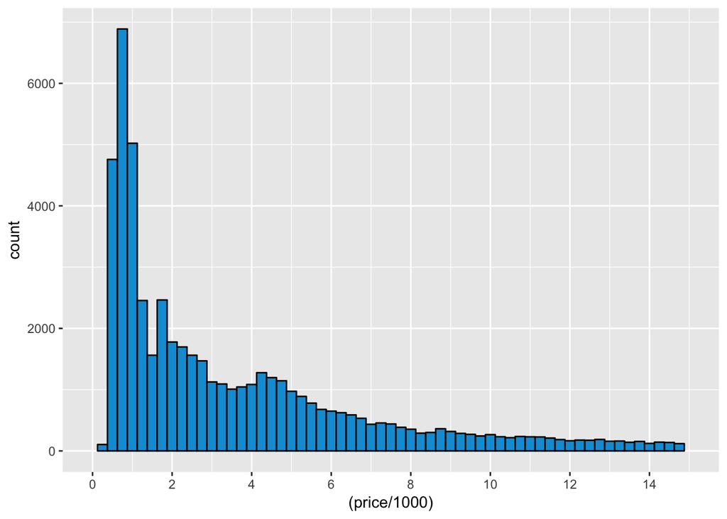

```r
qplot(data=diamonds, x=(price/1000), binwidth=0.25,
      color = I('black'), fill = I('#099DD9')) +
  scale_x_continuous(limits = c(0, 15), breaks = seq(0, 15, 2))
```

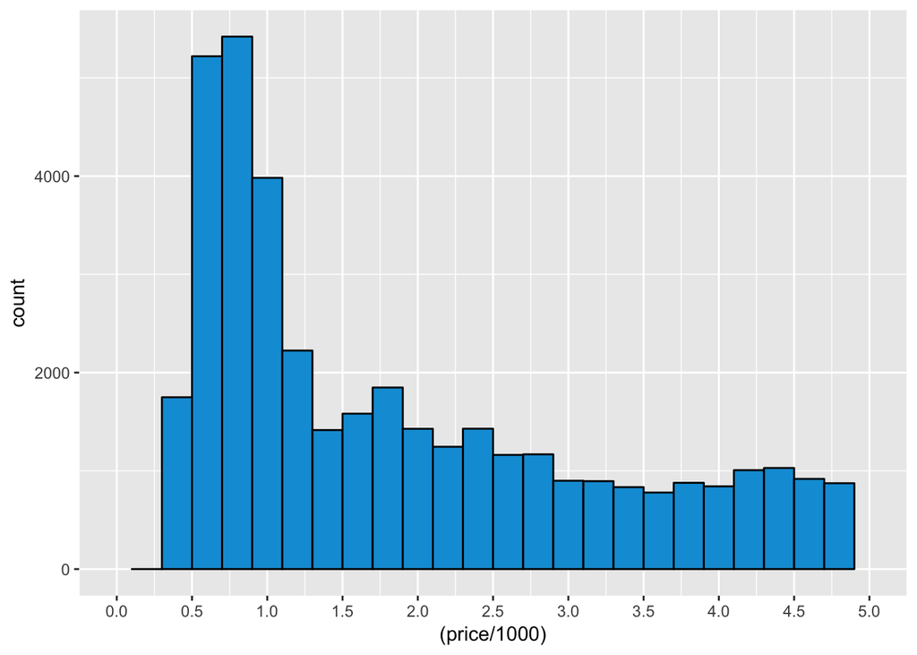

```r
qplot(data=diamonds, x=(price/1000), binwidth=0.2,
      color = I('black'), fill = I('#099DD9')) +
  scale_x_continuous(limits = c(0, 5), breaks = seq(0, 5, 0.5))
```

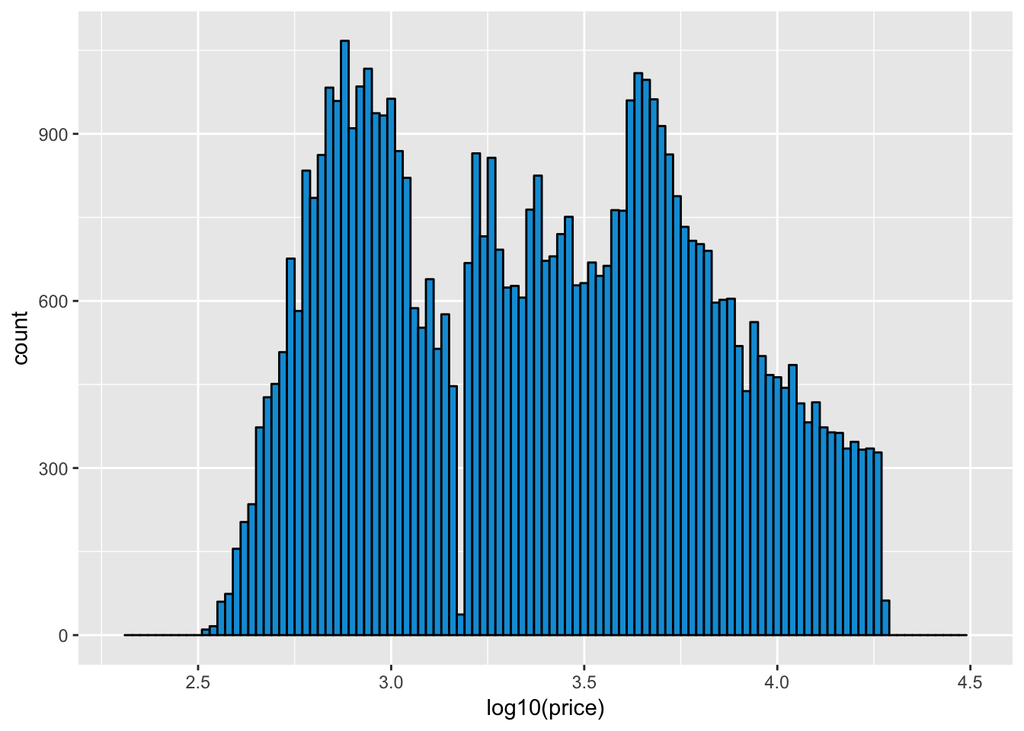

```r
qplot(data=diamonds, x=log10(price), binwidth = 0.02,
      color = I('black'), fill = I('#099DD9')) +
  scale_x_continuous(limits = c(2.3, 4.5), breaks = seq(0, 5 , 0.5))
```

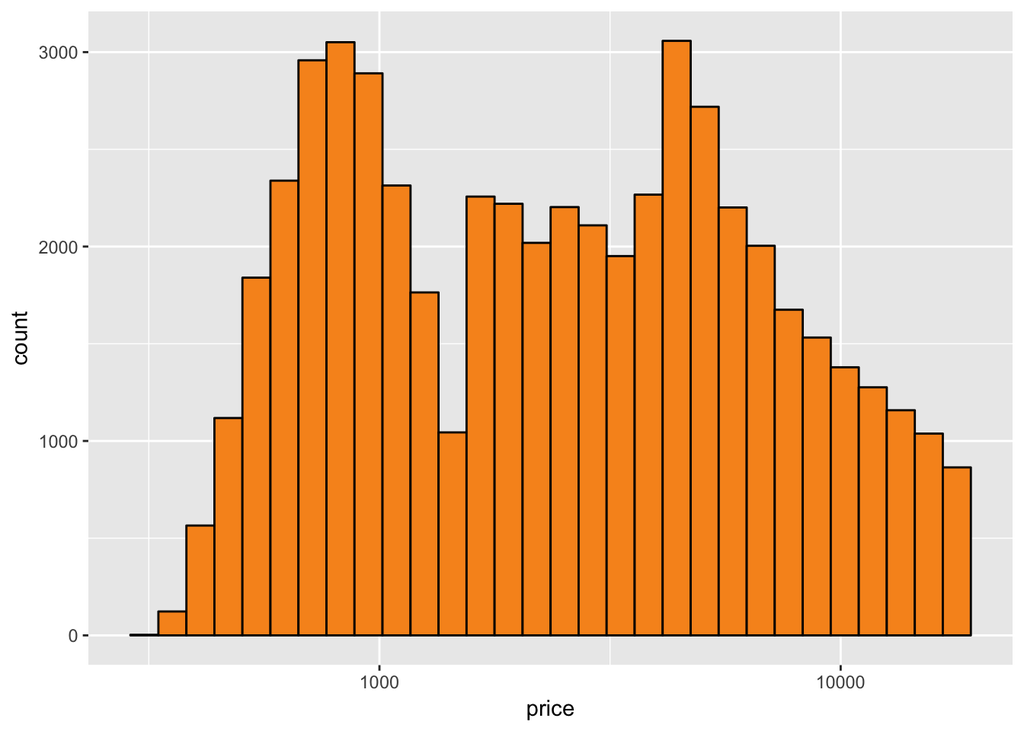

```r
ggplot(aes(x = price), data = diamonds) +
  geom_histogram(color = 'black', fill = '#F79420') +
  scale_x_log10()
```

Observations:

There are no diamonds that cost $1500.

For diamonds that cost less than $2,000, the most common price of a diamond is around $700 with the mode being $605 (binwidth = 1). The second insight comes from Paula F. Thanks Paula! Thank you for your submission!

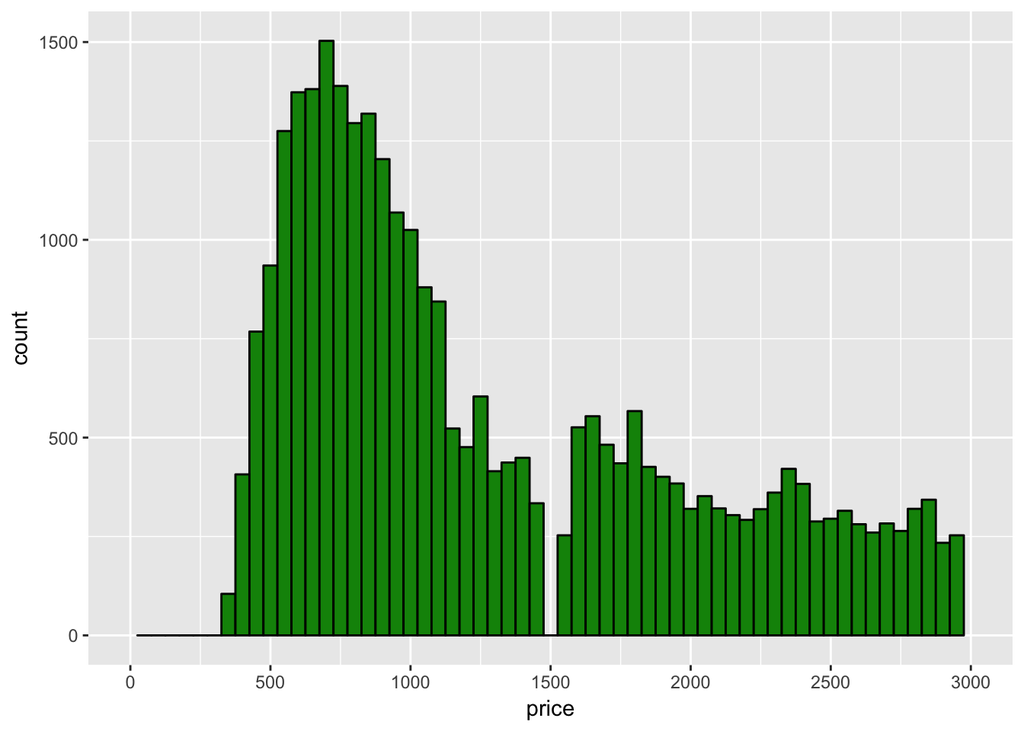

```r
qplot(x=price, data=diamonds, binwidth=50,
      color = I('black'), fill = I('#099009')) +
  scale_x_continuous(limits=c(0,3000), breaks = seq(0,3000,500))
```

## Price by cut Histograms

Break out the histogram of diamond prices by cut.

You should have five histograms in separate panels on you resulting plot.

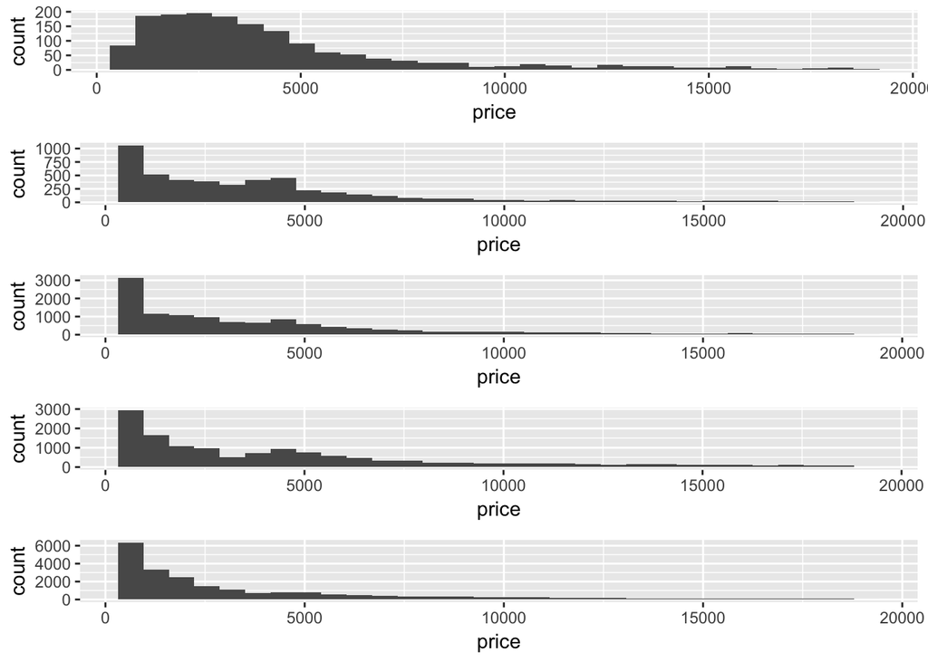

```r
library(gridExtra)

p1 <- ggplot(aes(x=price), data = subset(diamonds, diamonds$cut == 'Fair')) +
  geom_histogram()
p2 <- ggplot(aes(x=price), data = subset(diamonds, diamonds$cut == 'Good')) +
  geom_histogram()
p3 <- ggplot(aes(x=price), data = subset(diamonds, diamonds$cut == 'Very Good')) +
  geom_histogram()
p4 <- ggplot(aes(x=price), data = subset(diamonds, diamonds$cut == 'Premium')) +
  geom_histogram()
p5 <- ggplot(aes(x=price), data = subset(diamonds, diamonds$cut == 'Ideal')) +
  geom_histogram()

grid.arrange(p1,p2,p3,p4,p5, ncol=1)
```

Faceting:

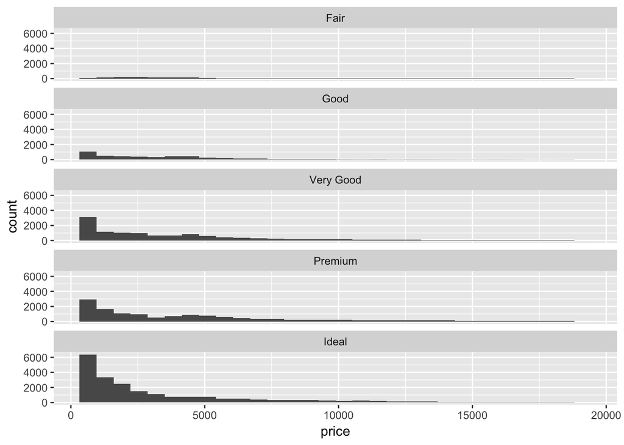

```r
qplot(x=price, data=diamonds) +
  facet_wrap(~cut, ncol = 1)
```

Frequency polygons:

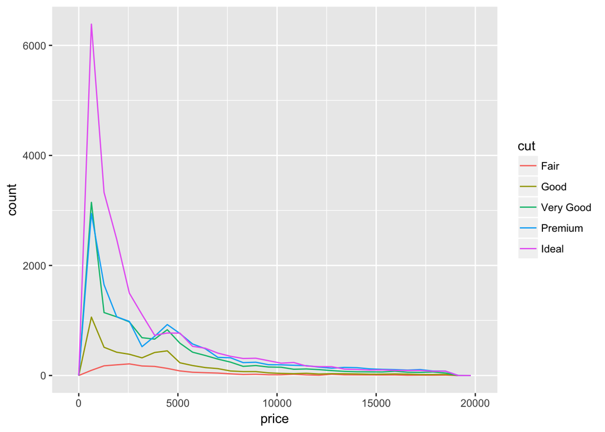

```r
ggplot(aes(x=price), data=diamonds) +
  geom_freqpoly(aes(color=cut))
```

## Price by Cut

1. Which cut has as the highest priced diamond?

```r
by(diamonds$price, diamonds$cut, summary)
```

```
## diamonds$cut: Fair
##    Min. 1st Qu.  Median    Mean 3rd Qu.    Max.
##     337    2050    3282    4359    5206   18570
## --------------------------------------------------------
## diamonds$cut: Good
##    Min. 1st Qu.  Median    Mean 3rd Qu.    Max.
##     327    1145    3050    3929    5028   18790
## --------------------------------------------------------
## diamonds$cut: Very Good
##    Min. 1st Qu.  Median    Mean 3rd Qu.    Max.
##     336     912    2648    3982    5373   18820
## --------------------------------------------------------
## diamonds$cut: Premium
##    Min. 1st Qu.  Median    Mean 3rd Qu.    Max.
##     326    1046    3185    4584    6296   18820
## --------------------------------------------------------
## diamonds$cut: Ideal
##    Min. 1st Qu.  Median    Mean 3rd Qu.    Max.
##     326     878    1810    3458    4678   18810
```

Try again:

Try using max as the function inside of the by command. The summary function does some rounding.

You could also use digits = max(getOption(‘digits’)) as a fourth argument in the by command. Any arguments after the function in the by command get passed to that function.

```r
by(diamonds$price, diamonds$cut, max)
```

```
## diamonds$cut: Fair
## [1] 18574
## --------------------------------------------------------
## diamonds$cut: Good
## [1] 18788
## --------------------------------------------------------
## diamonds$cut: Very Good
## [1] 18818
## --------------------------------------------------------
## diamonds$cut: Premium
## [1] 18823
## --------------------------------------------------------
## diamonds$cut: Ideal
## [1] 18806
```

- premium only

```r
by(diamonds$price, diamonds$cut, median)
```

```
## diamonds$cut: Fair
## [1] 3282
## --------------------------------------------------------
## diamonds$cut: Good
## [1] 3050.5
## --------------------------------------------------------
## diamonds$cut: Very Good
## [1] 2648
## --------------------------------------------------------
## diamonds$cut: Premium
## [1] 3185
## --------------------------------------------------------
## diamonds$cut: Ideal
## [1] 1810
```

## Scales and Multiple Histograms

In the last two exercises, we looked at the distribution for diamonds by cut.

Run the code below in R Studio to generate the histogram as a reminder.

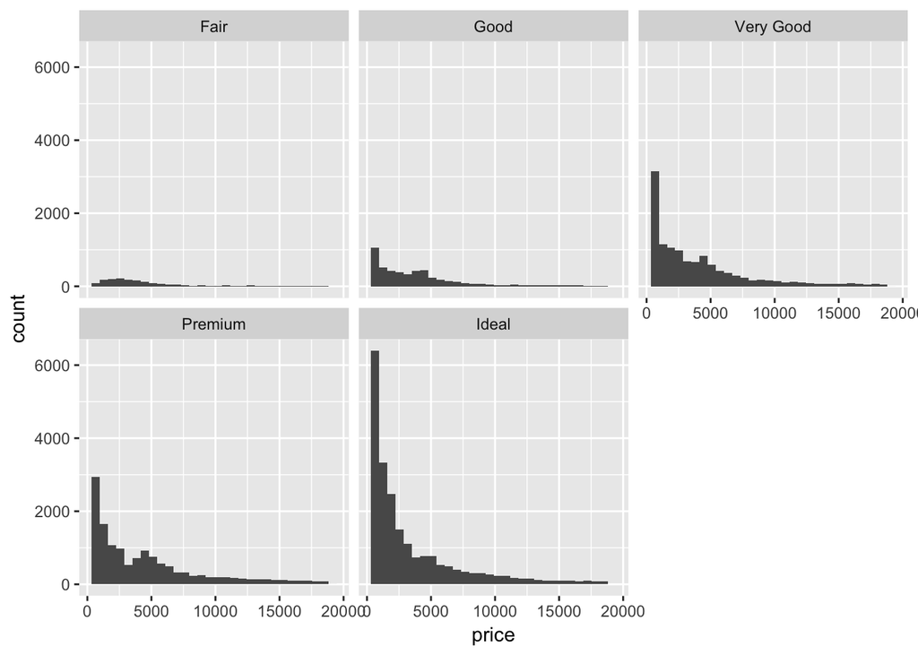

```r
qplot(x = price, data = diamonds) + facet_wrap(~cut)
```

In the last exercise, we looked at the summary statistics for diamond price by cut. If we look at the output table, the median and quartiles are resonably close to each other.

```r
by(diamonds$price, diamonds$cut, summary)
```

```
## diamonds$cut: Fair
##    Min. 1st Qu.  Median    Mean 3rd Qu.    Max.
##     337    2050    3282    4359    5206   18570
## --------------------------------------------------------
## diamonds$cut: Good
##    Min. 1st Qu.  Median    Mean 3rd Qu.    Max.
##     327    1145    3050    3929    5028   18790
## --------------------------------------------------------
## diamonds$cut: Very Good
##    Min. 1st Qu.  Median    Mean 3rd Qu.    Max.
##     336     912    2648    3982    5373   18820
## --------------------------------------------------------
## diamonds$cut: Premium
##    Min. 1st Qu.  Median    Mean 3rd Qu.    Max.
##     326    1046    3185    4584    6296   18820
## --------------------------------------------------------
## diamonds$cut: Ideal
##    Min. 1st Qu.  Median    Mean 3rd Qu.    Max.
##     326     878    1810    3458    4678   18810
```

This means that the distributions should be somewhat similar, but the histograms we created don’t show that.

The ‘Fair’ and ‘Good’ diamonds appear o have different distributions compared to the better cut diamonds. They seem somewhat uniform on the left with long tails on the right.

Let’s look into this more.

Look up the documentation for facet_wrap in R studio. Then, scroll back up and add a parameter to facet_wrap so that the y-axis in the histograms is not fixed. You want the y-acis to be different for each histogram.

```r
?facet_wrap
```

See also:

http://www.cookbook-r.com/Graphs/Facets_(ggplot2)/

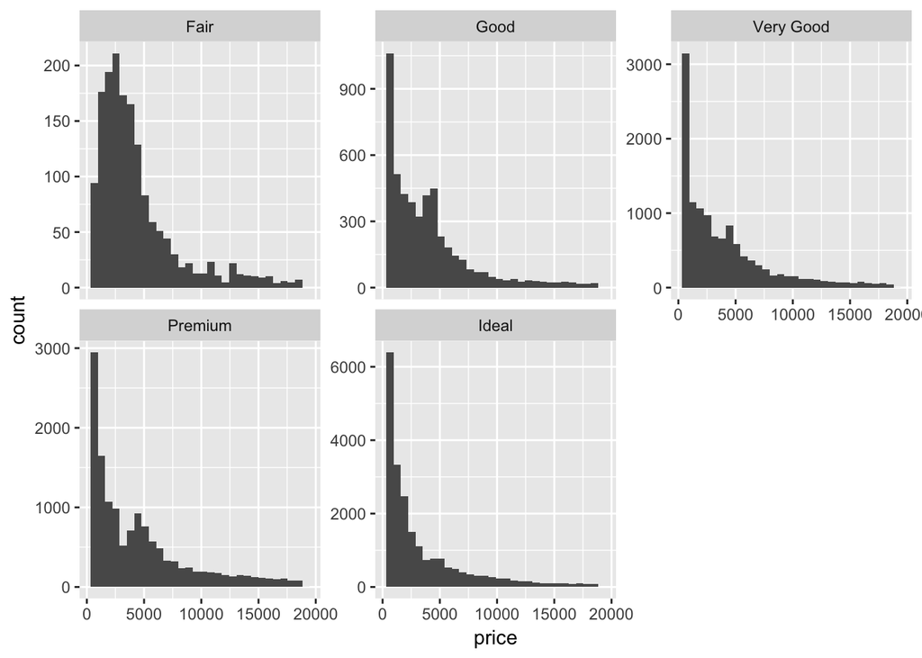

```r
qplot(x = price, data = diamonds) + facet_wrap(~cut, scale='free_y')
```

Are your y-axis scales different on some of the panels?

It’s a good idea to consider the scales when you create plots.

Don’t worry if the mean and median prices of diamonds seem unintuitive right now. In later lessons, we’ll learn the tools to understand what’s causing these patterns.